# FORECASTING FINAL PROJECT

### 4.0.10 **Conclusion**

The **Multiplicative Prophet model** struggles to provide precise forecasts, with large error margins and strong autocorrelation in residuals. The underperformance is evident from the RMSE, MAPE, and the misalignment of predictions with actual data in certain periods. Alternative modeling approaches, such as fine-tuning changepoints, using external regressors, or selecting a different model (e.g., ARIMA or hybrid models), may improve accuracy.

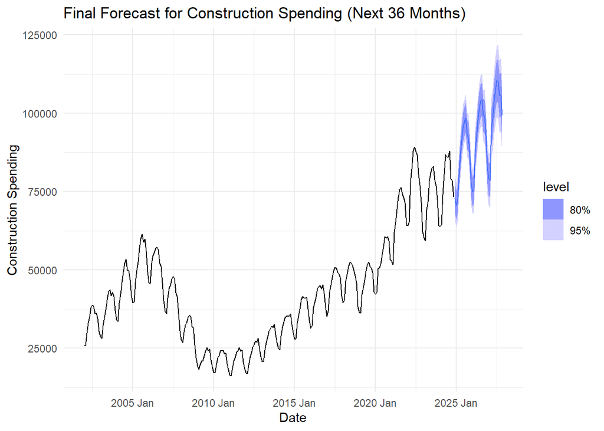

```r
# Load necessary libraries
library(tidyverse)
library(tsibble)
library(fable)
library(fable.prophet)

# Combine train and test data into a single dataset
full_data <- bind_rows(train_data, test_data) %>%
  arrange(date) %>%
  as_tsibble(index = date)

# Fit the final Prophet model on the full dataset
final_prophet_model <- full_data %>%
  model(
    multiplicative_prophet = prophet(
      construction_spending ~ growth("linear") +
      season(period = "year", type = "multiplicative")  # Adjusting sensitivity to trend changes
    )
  )

# Generate a 12-month forecast
final_forecast <- final_prophet_model %>%
  forecast(h = "36 months")

# Plot the forecast
autoplot(final_forecast, full_data) +
  ggtitle("Final Forecast for Construction Spending (Next 36 Months)") +
  labs(x = "Date", y = "Construction Spending") +
  theme_minimal()
```

### 4.0.11 **Interpretation of the Final Forecast for Construction Spending (Next 36 Months)**

The plot presents the **final forecast** for construction spending over the next **36 months**, using a time-series forecasting model. The **black line** represents historical actual values, while the **blue shaded regions** indicate the model’s forecast along with **80% and 95% confidence intervals**.

#### 4.0.11.1 **Key Observations:**

1. **Upward Trend**: The forecast continues to show a **strong increasing trend**, suggesting sustained growth in construction spending.
2. **Seasonality Captured**: The forecasted values maintain the periodic seasonal pattern observed in historical data.
3. **Uncertainty Representation**: The shaded areas widen over time, indicating **greater uncertainty** in long-term forecasts. The **darker blue** represents the **80% confidence interval**, while the **lighter blue** represents the **95% confidence interval**.
4. **Reliable Short-Term Forecast**: In the **initial forecast period**, the confidence intervals are narrower, suggesting greater reliability. However, as the forecast extends further, the range expands, implying increasing uncertainty.

#### 4.0.11.2 **Conclusion:**

The model suggests **continued growth in construction spending**, with expected seasonal variations. However, as forecast uncertainty increases over time, decision-makers should exercise caution when using longer-term projections. Regular updates with new data and potential model refinements may help improve forecast accuracy.